# Kickstarter Data Analysis

Matt McGinnis, Mirella Rodriguez, Carlos Santillana, Daniel Ledesma, Patrick Nassar

# Introduction

Kickstarter is an online crowdfunding website, which allows users create their own campaigns, with the goal of getting people to donate to their idea. The main purpose of starting a campiagn is to raise a certain amount of funds needed to “help bring creative projects to life”. These projects can include comic books,music,design, video games, technology and many others. In order for some campaigns to receive donations the user will sometimes offfer the donors, a greater return based on the donation amount e.g. if someone donates $1000 to a video game campain they can get their name in the credits of the game or perhaps receive a special edition of the game, due to their high donation amount.

# Kickstarter Dataset

The kickstarter dataset we used in this project ,included over 300,000 campaigns from the years 2008-2018. Each campaign had their own ID number, lauch date, deadline date, number of backers, pledged amount, amount earned in US dollars, country in which the campaign began and the state of each campaign i.e succes,fail,live,canceled. In this dataset the majority of campaigns began in the United States. This is due Kickstarter being created in the United States ,as well as, some countries were not granted access to begin kickstarters campaign until years after the original launch of the website (2008); Japan,for example, was not able to open kickstarter until 2017.

## Analysis

The analysis we will be incporporating to this dataset includes exploratory data analysis (EDA), which mainly involves examining count data and looking at different plots and graphs i.e bar graphs, dot plots, and histograms. We wil also be looking at different classification methods such as logistic regression, validation set approach, decision boundaries and K Nearest Neighbors (KNN). When then plan to apply this model to current campaigns , to determine whether a certain campaign will succeed or fail.

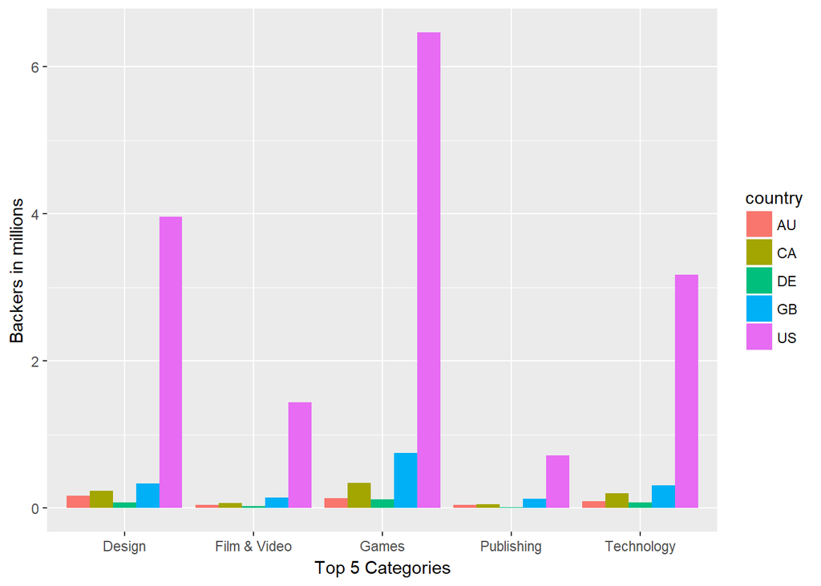

In this graph, we wanted to determine which category had the most amount of backers excluding the amount paid from the backers. The U.S. surpasses all the rest of the countries by a significant amount. In the U.S, Games category is backed the most with Design as 2nd. Around 6500000 backers supported Games while the next country, Great Britain, only has around 750000 backers.

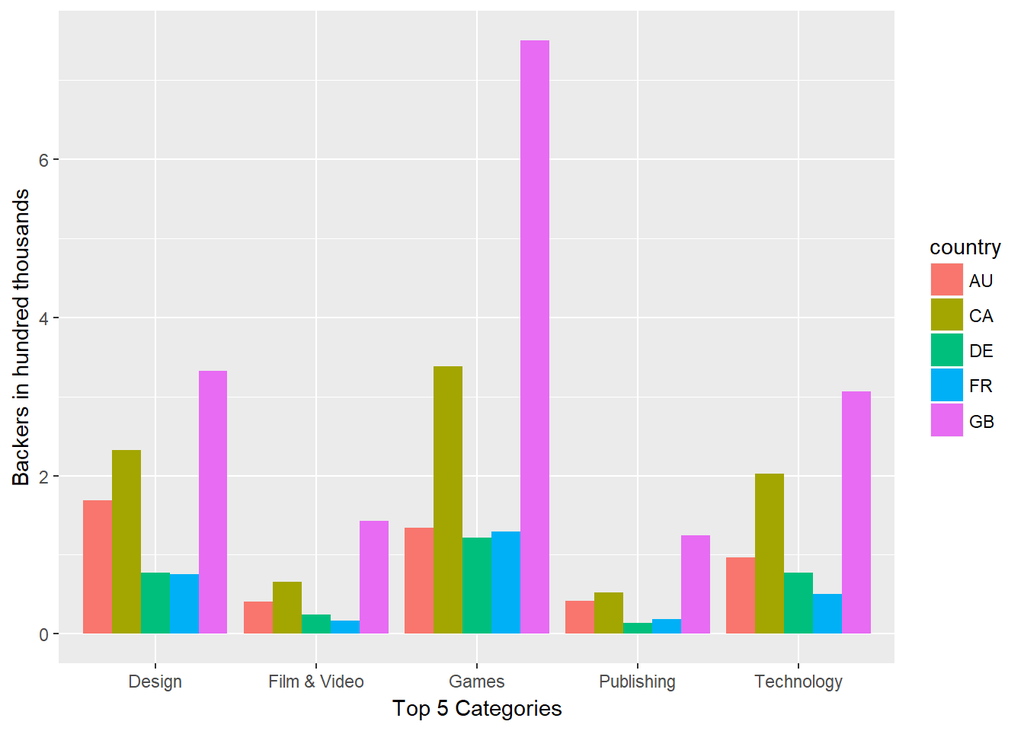

Since the United States had significantly more backers than the rest of the countries, we decided to make a histogram without the U.S. in it. The data shows Great Britain having the most amount of backers in all categories with Canada coming in 2nd in all categories. Similar to the above histogram, Games is the most backed up category with Design in 2nd. The data also shows that Games is the most backed category in ALL countries except for Australia which has the most backers in Design.

### Boxplots for top 5 categories for all countries.

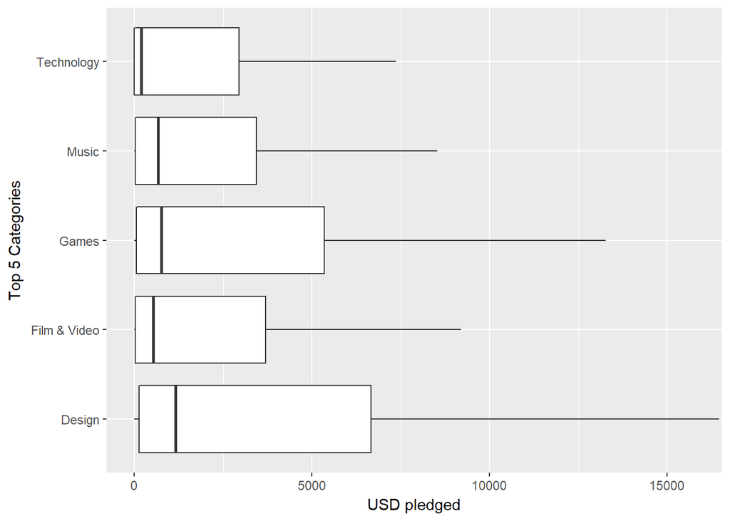

When dealing with the kickstarter data, the first question we wanted to tackle was what were the five most popular categories that received the most funding from backers in all countries. The top 5 categories were picked by the number of backers, and ordered from most backed to least backed. In determining the highest funded category, we can propose which category is valued to have the most likeable ideas for potential backers to donate their money towards. We decided to create a boxplot to visualize the data. On the y-axis are the top five main categories, which most backers donated towards. On the x-axis we have amount donated in U.S. dollars. Medians were incredibly low because the number of failed campaigns is very high. The median amount donated is highest in the Design category. Also, Design has the biggest range of amount donated compared to the other four categories. All categories have a Q1 starting around $250, a low median, and a high Q3 compared to the median. Q3’s are substantially different. Q3 for Design is the most around $6500. Games comes in 2nd having a close Q3 around $5250. The long right whisker implies heavy right tail meaning there are few projects which make much of the money pledged. This boxplot shows us that backers are most likely to donate to an idea related in the Design category all countries. The boxplot can also help budding enterprises see how much money to expect in funding from launching a campaign.

### Boxplots for Top 5 countries outside of US for top 5 categories

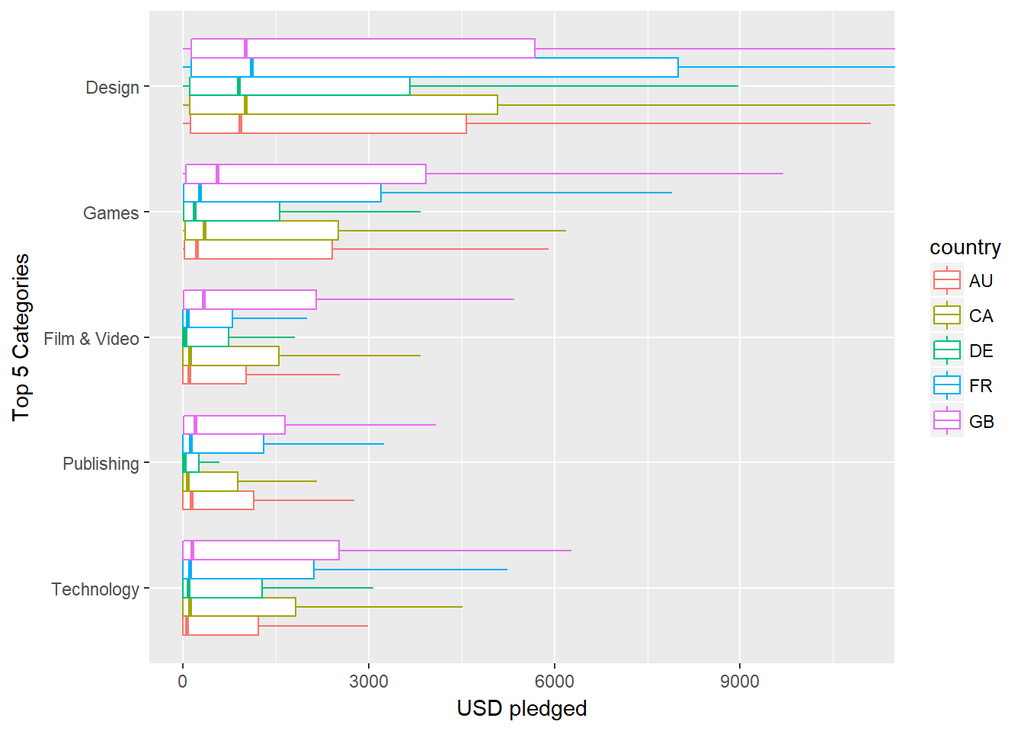

We decided to take it one step further and include an individual boxplot per country per top 5 category excluding the U.S markets. While U.S. dominates Kickstarter the other countries still make up a significant minority; therefore, being an interesting visual of other market relationships. Shown in the graph, are the countries of Australia (AU), Canada (CA), Germany (DE), France (FR), and Great Britain (GB). On the y-axis are the top five main categories which most backers donated towards. On the x-axis we have amount donated in U.S. dollars. When looking at all 5 categories, Great Britain has the most amount donated in all categories except Design. France has the most backed projects in Design by a significant difference having a Q3 of around $8000 and a larger median than Great Britain which comes in 2nd. Design category has most amount of money pledged. Through this chart we can advise a person who wants to build a project on Kickstarter to make their project idea in the Design category.

### Boxplots for top 5 categories for only US.

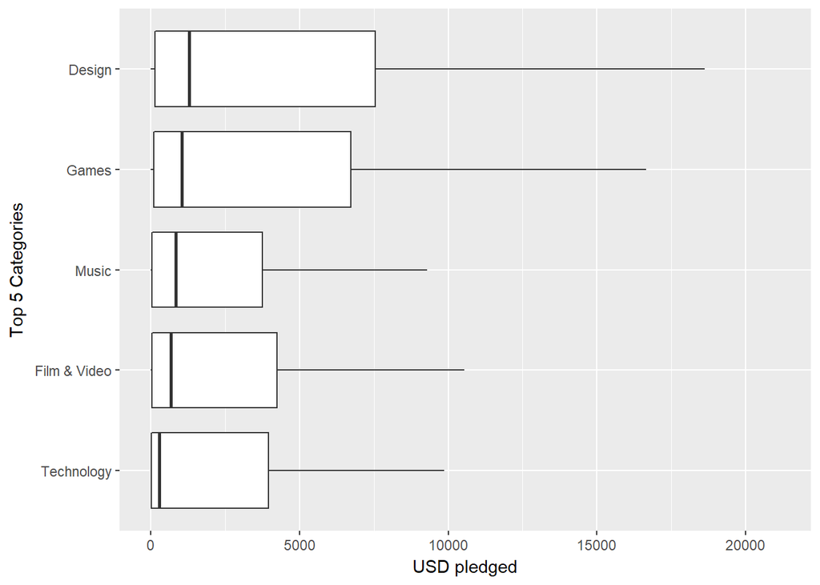

The third question we wanted to tackle was what were the five most popular categories that received the most funding from backers in the United States, since the U.S. makes up for a significant majority. It was important to see trends within the U.S. market rather than seeing trends worldwide. In determining the highest funded category, we can propose which category is valued to have the most likeable ideas for potential backers to donate their money towards. We decided to create a boxplot to visualize the data. On the y-axis are the top five main categories, which most backers donated towards. On the x-axis we have amount donated in U.S. dollars. The median amount donated is again highest in the Design category. Also, Design has the biggest range of amount donated compared with the other four categories. All categories have a Q1 starting around 250 dollars, a low median, and a higher Q3 in comparison to the respective median. The Q3’s are substantially different. Q3 for Design is the most around 7500 dollars. Games comes in 2nd having a close Q3 around 6500 dollars. Film & Video comes in third with a Q3 around 4000 dollars. This boxplot shows us that backers in the U.S. are most likely to donate to an idea related in the Design category. Also, backers are seen to likely donate to the Games category. Additionally, this boxplot can help give entrepreneurs an estimate on what to expect during their own campaign, and let them devise a market strategy accordingly.

### Ratio of sucessful to canceled and failed project for the top five categories, for all countries.

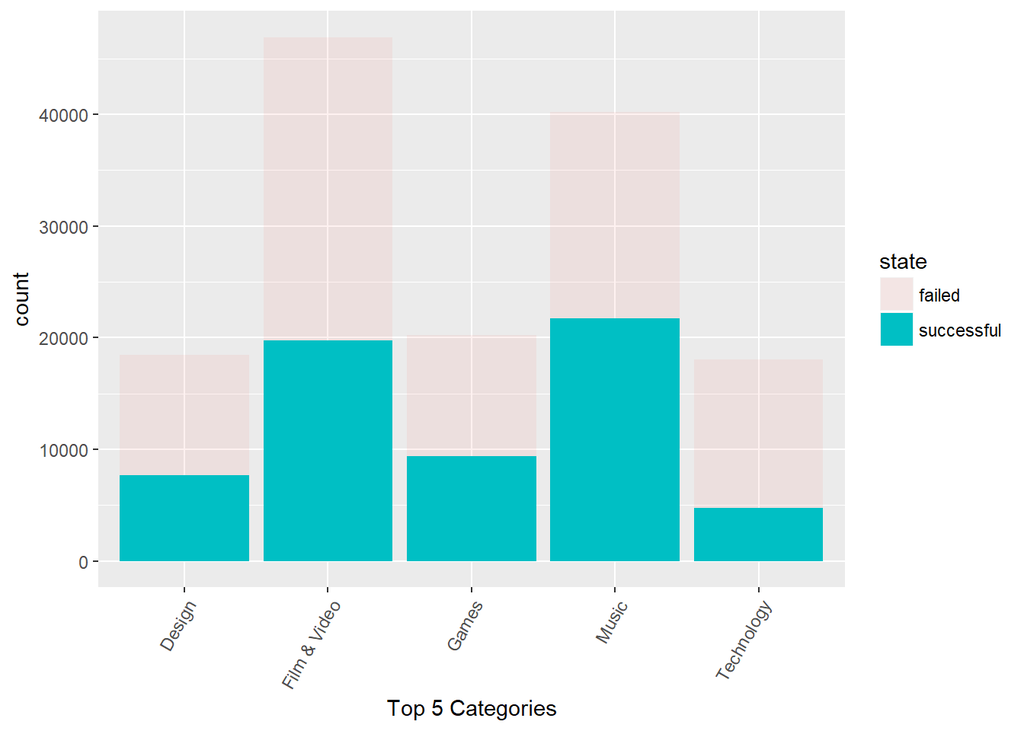

We wanted to determine the ratio of successful and failed projects in these top 5 categories to help consumers and entrepreneurs before they decide to invest their time and money into Kickstarter. By viewing the ratio of success to failure, consumers and entrepreneurs can make informed and less risky decisions. This chart takes into consideration all countries. On the y-axis is number of projects. On the x-axis is top 5 categories. Music has more successful projects than failed ones. On the other hand, Design, Film & Video, Games, and Technology have more failed projects than successful projects. Music has the most successful projects reaching a little above 20000. Film & Video comes in at close second reaching right under 20000. Also, Film & Video has most projects made in all countries with Music coming in 2nd. Best ratio for consumers and entrepreneurs to look into is the Music category.

## Indiegogo Data Comparison.

Next, we wanted to compare the Kickstarter data to its competitor Indiegogo. By comparing the top 5 categories between the two platforms, entrepreneurs can decide which is the better website to promote their product. Seen by the boxplots, Technology products do significantly better on Indiegogo than on Kickstarter. Although having different ratios between the two platforms, Film & Video roughly has the same success to fail ratio. The only issue with comparing both platforms is that Indiegogo also includes charities as well as products for each category. This causes a skewness in our results. From what we know, we can advise entrepreneurs to stick with Kickstarter. Charity work is high in revenue and brings good moral towards consumers, which can account for the significant increase in amount pledged in Indiegogo.

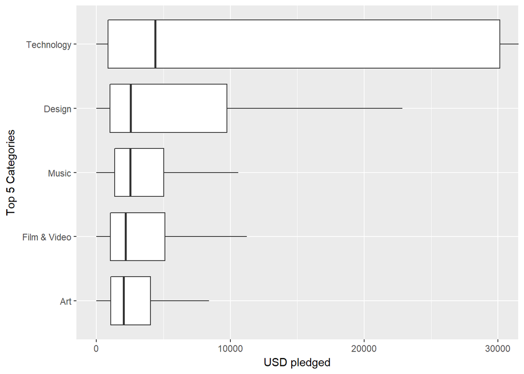

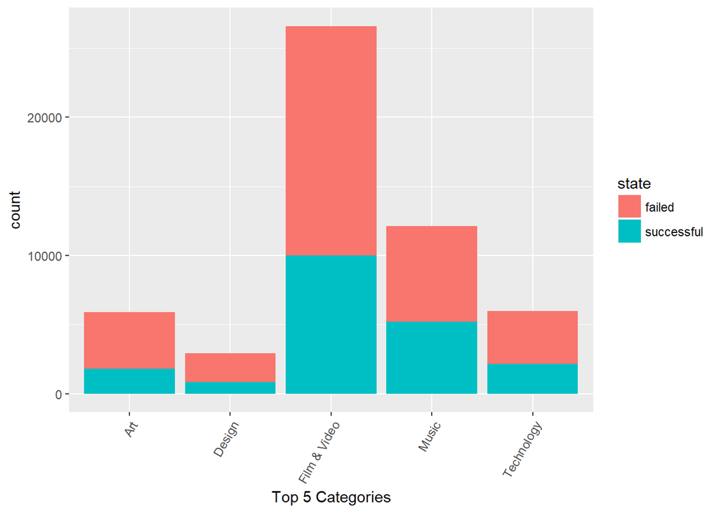

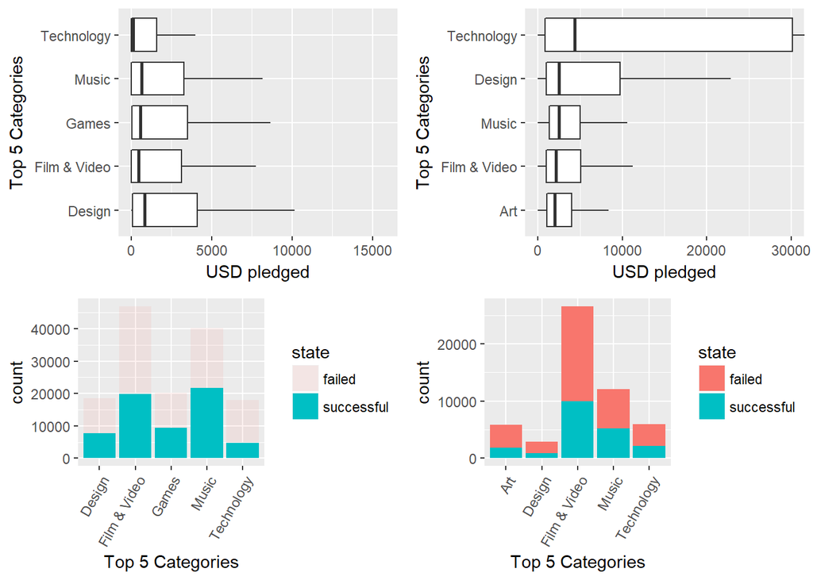

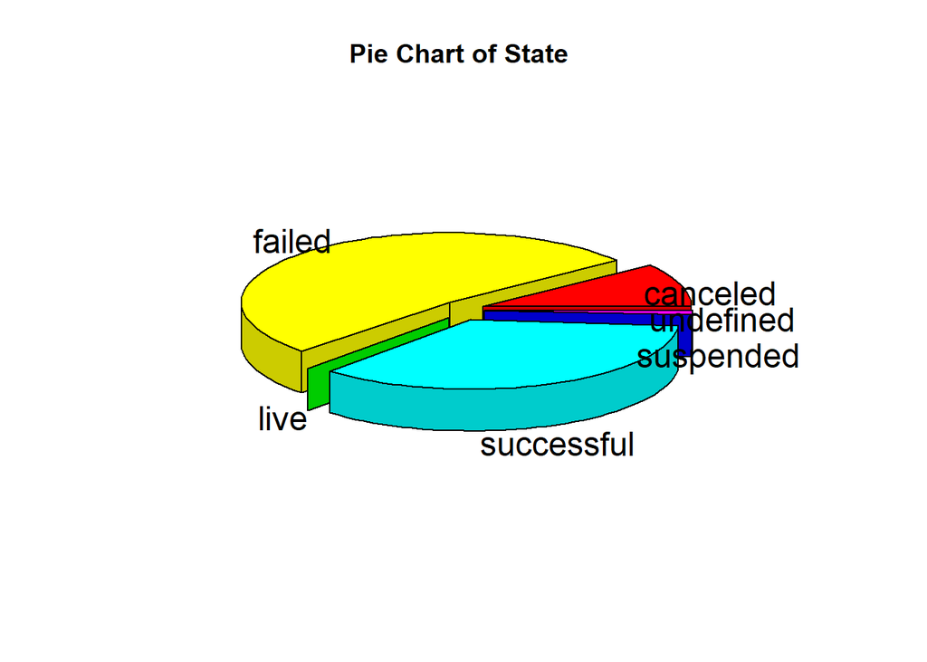

The pie chart above shows the proportion of campaigns in each state - successful, failure, undefined, suspended, canceled, and live. Approximately half of the campaigns in the dataset “failed,” while about 35% of the campaigns were successful. The remaining states are live, undefined, and suspended. Live means that the campaign has not ended yet. We are interested in looking at the data for past campaigns that were either a success or a fail.

We filtered the original data set so the state of the campaign is either a success or a fail. We want to build a classification model (logistic regression) to predict whether the campaign will be a success or a fail. With a model like this built, we want to detect the curent status of the live campaigns if the campaign were to end at the present moment, and calculate the additional number of backers needed to improve the probability of a successful campaign to more than 50%. If we do calculate the probability as more than 50%, then we classify this as a success.

From this filtered data, we take a random sample of 199,005, which is 60% of the data. We used the validation set approach to evaluate our model. This data will be trained to fit a model while the remaining 40% will be tested using this model.

With this random sample, we fit our first logistic regression model using most of the variables given in the dataset. The $\beta$ parameter estimates are listed below, as well as their standard errors.

```
##
## Call:
## glm(formula = successfail ~ goal + pledged + backers + usd.pledged +
##     usd_pledged_real + usd_goal_real, family = binomial(), data = success_or_fail2)
##
## Deviance Residuals:
##    Min      1Q  Median      3Q     Max
##  -8.49    0.00    0.00    0.00    8.49
##
## Coefficients:
##                    Estimate Std. Error z value Pr(>|z|)
## (Intercept)       1.3282179  0.0701867  18.924  < 2e-16 ***
## goal             -0.0281091  0.0079832  -3.521 0.000430 ***
## pledged           0.0281067  0.0080022   3.512 0.000444 ***
## backers           0.0660804  0.0081034   8.155 3.50e-16 ***
## usd.pledged      -0.0002898  0.0002372  -1.222 0.221783
## usd_pledged_real  0.0689870  0.0083901   8.222  < 2e-16 ***
## usd_goal_real    -0.0682687  0.0084005  -8.127 4.41e-16 ***
## ---
## Signif. codes:  0 '***' 0.001 '**' 0.01 '*' 0.05 '.' 0.1 ' ' 1
##
## (Dispersion parameter for binomial family taken to be 1)
##
##     Null deviance: 268338  on 198886  degrees of freedom
## Residual deviance:   1774  on 198880  degrees of freedom
##   (118 observations deleted due to missingness)
## AIC: 1788
##
## Number of Fisher Scoring iterations: 25
```

# Fit the reduced model.

In this model, we eliminated the variables goal, pledged, and usd.pledged. When visualized on a test grid, there would not be an obvious distinction between a successful and a failed campaign when these variables are used. Additionally, we are interested in fitting the simplest model that still makes accurate predictions. We risk overfitting the model if too many predictors are utilized. The model is then refit, keeping backers and usd_goal_real in the model.

```
##
## Call:
## glm(formula = successfail ~ backers + usd_goal_real, family = binomial(),
##     data = success_or_fail2)
##
## Deviance Residuals:
##     Min       1Q   Median       3Q      Max
## -8.4904  -0.6016  -0.0281   0.3113   8.4904
##
## Coefficients:
##                 Estimate Std. Error z value Pr(>|z|)
## (Intercept)   -8.615e-01  8.482e-03  -101.6   <2e-16 ***
## backers        5.448e-02  2.979e-04   182.9   <2e-16 ***
## usd_goal_real -2.347e-04  1.586e-06  -148.0   <2e-16 ***
## ---
## Signif. codes:  0 '***' 0.001 '**' 0.01 '*' 0.05 '.' 0.1 ' ' 1
##
## (Dispersion parameter for binomial family taken to be 1)
##
##     Null deviance: 268511  on 199004  degrees of freedom
## Residual deviance: 129631  on 199002  degrees of freedom
## AIC: 129637
##
## Number of Fisher Scoring iterations: 13
```

With this model fitted, binary predictions can be made with a given set of inputs. If the probability of success is 0.5 or above, the campaign is classified as “successful.” Otherwise, the campaign is classified as a “failure” by our model.

```
## # A tibble: 20 x 3
##             probability classify classify2
##                   <dbl>    <dbl> <chr>
##  1 1.000                    1.00 successful
##  2 0.000000000000000222     0    failure
##  3 0.130                    0    failure
##  4 0.199                    0    failure
##  5 0.000389                 0    failure
##  6 0.173                    0    failure
##  7 0.0203                   0    failure
##  8 0.945                    1.00 successful
##  9 0.0702                   0    failure
## 10 0.950                    1.00 successful
## 11 0.258                    0    failure
## 12 0.00141                  0    failure
## 13 0.149                    0    failure
## 14 0.189                    0    failure
## 15 1.000                    1.00 successful
## 16 0.178                    0    failure
## 17 0.400                    0    failure
## 18 0.142                    0    failure
## 19 1.000                    1.00 successful
## 20 1.000                    1.00 successful
```

# Model Evaluation

### Training Set

To evaluate the model we have fit, we must examine the misclassification rate for the training set. Of course, the classifications made by the model will sometimes deviate from the truth. For instance, sometimes a camapign may be classified as a success while it was a failure in reality. In contrast, a campaign may be classified as a failure when it was actually a success. Hence, minimizing this error rate as much as possible is ideal, as it will help us make more accurate prediction of live campaigns that we do not know the status of. At the same time, we do not wish to overfit our data with too many predictors.

```
## # A tibble: 2 x 2
## # Groups:   match [2]
##   match      n
##   <lgl>  <int>
## 1 F      20427
## 2 T     178578
```

The misclassification rate on the training set of 199005 observations is 10.26%. We can break this down further to see how many campaigns were falsely predicted as a success or a failure. To do this, we made a confusion matrix. The 0 represents failure while a 1 represents a success.

```
##
##          0      1
##   0 113641  15478
##   1   4949  64937
```

Calculate Sensitivity and Specificity

- Sensitivity / Recall / Power / True Positive Rate (TPR)

$$\begin{aligned}
= & \frac{\# \text{ observations correctly classified to have the event}}{\# \text{ observations that had the event}} \\
= & \frac{TP}{TP+FN} = \frac{TP}{P}
\end{aligned}$$

```
## [1] 0.8075235
```

- Specificity / True Negative Rate (TNR)

$$\begin{aligned}
= & \frac{\# \text{ observations correctly classified as non-events}}{\# \text{ observations that did not have the event}} \\
= & \frac{TN}{TN+FP}= \frac{TN}{N}
\end{aligned}$$

```
## [1] 0.958268
```

Next we should generate an ROC curve.

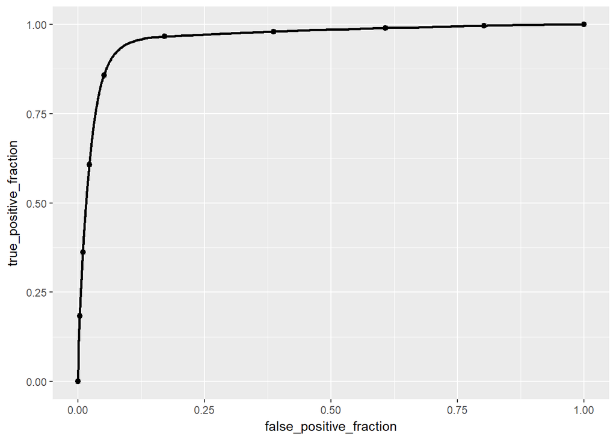

The ROC curve shows that the model has good accuracy. The closer the curve is to the upper left hand corner, the better.

### Validation Set

Now, let’s see how the model performs with the testing set. Once again, we calculate the misclassification rate. First of all, the table below shows some of the predictions on the test set.

```
## # A tibble: 20 x 3
##             probability classify classify2
##                   <dbl>    <dbl> <chr>
##  1 0.839                    1.00 successful
##  2 0.116                    0    failure
##  3 1.000                    1.00 successful
##  4 0.415                    0    failure
##  5 0.383                    0    failure
##  6 1.000                    1.00 successful
##  7 0.217                    0    failure
##  8 0.937                    1.00 successful
##  9 0.640                    1.00 successful
## 10 0.117                    0    failure
## 11 0.446                    0    failure
## 12 0.00610                  0    failure
## 13 0.189                    0    failure
## 14 0.999                    1.00 successful
## 15 1.000                    1.00 successful
## 16 1.000                    1.00 successful
## 17 0.0483                   0    failure
## 18 1.000                    1.00 successful
## 19 0.000000000000000222     0    failure
## 20 0.0208                   0    failure
```

```
## # A tibble: 2 x 2
## # Groups:   match [2]
##   match      n
##   <lgl>  <int>
## 1 F      13725
## 2 T     118945
```

Confusion matrix:

```
##
##         0     1
##   0 75827 10423
##   1  3302 43118
```

The testing set misclassification rate is 10.34%, which indicates that the model is consistent with predicting whether or not a campaign will be a success or a failure.

Calculate Sensitivity and Specificity

- Sensitivity / Recall / Power / True Positive Rate (TPR)

```r
43118/(43118+10423)
```

```
## [1] 0.8053268
```

- Specificity / True Negative Rate (TNR)

```r
75827/(75827+3302)
```

```
## [1] 0.9582707
```

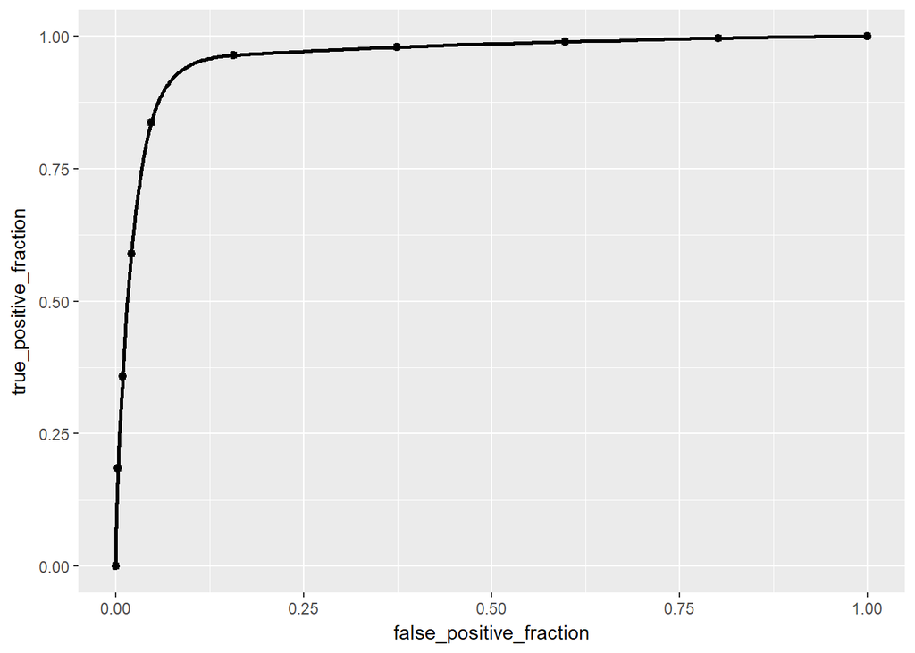

The ROC curve indicates that the model makes accurate predictions on the validation set.

## Test grid

We generate a test grid and a decision boundary line to see for what values of backer and usd_goal_real is the campaign classified as a success or a fail.

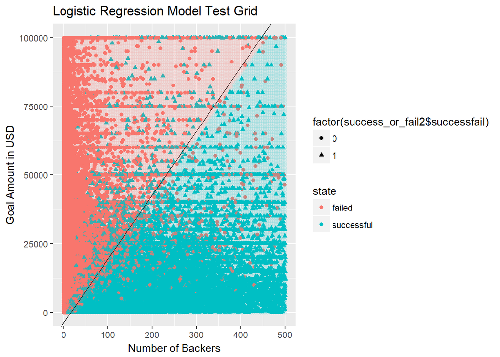

The test grid plot shows us a clear decision boundary in which a campaign will be classified as a success (blue) or a fail (pink) based on what the campaign’s goal is and how many backers they have. Ideally, we want to utilize this model on the live campaigns that have not reached their deadlines. With this we can find how many more backers a live campaign will need with its goal staying constant. If a live campaign lies in the pink region, this indicates that the model predicts the campaign failing if the campaign were to theoretically end at the present time. Consequently, it will need a certain number of backers by the campaign deadline in order to be classified as a successful campaign. If the live campaign already has the right amount of backers to classify it as a successful campaign, then we are not concerned about how more backers we will need to reach the goal amount. As the plot above shows, the decision boundary is a line. As the goal in us dollars increases, the number of backers needed for a campaign to be successful increases.

One application of this model is on the campaign entitled “20th Anniverary Celebration: The Animation Show of Shows.” It is a live campaign that currently has 239 backers and a goal of 61,500 usd. As of right now, our model classifies it as a failed campaign, but if it were to acquire 42 more backers over the next 10 days, it would be classified as a success by our model. The probability of success would increase.

A second application of the model is the campaign called “Tiny Climbers,” which are mini rock climbing magnets and pins. There are currently 58 backers with a goal of 28000 USD. In 22 days, it needs 79 more backers for our model to classify it as a successful campaign.

In addition to the logistic regression model, we also considered K nearest neighbors as a classification model to predict whether or not a campaign will be successful or not. The same variables as the logistic regression model were used.

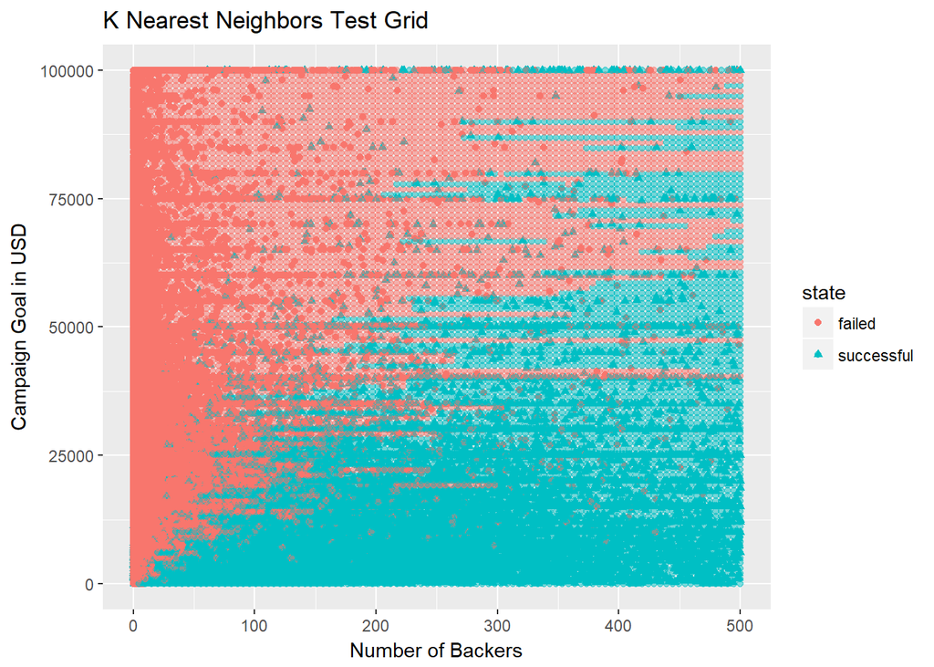

Even though the test grid shows a more dynamic and detailed decision boundary, we will use the logistic regression for simplicity when we calculate how many more backers are needed to predict a successful campaign.

## Conclusion

To summarize, our analysis covered a variety of topics ranging from exploratory data analysis to building a classification model in order to predict the success or failure of a Kickstarter project. We began by taking an overall glance at our data which led us to narrow our focus on countries, popular categories, and the number of backers. We noticed a majority of data points were from the United States, so we decided to look at the trends based on location. We filterted our data to show only the United States and another excluding the United States for the most popular categories. We furthered our research and compared these top five categories to another crowd-funding site Indiegogo. We wanted to compare the top five categories on each site, in order to help future project-seekers choose the site that will result in a successful kickstarter.

Subsequently, we further investigated the ratio of success and failures for both Kickstarter and Indiegogo. This led us to think, “Can we predict whether a campaign will succeed or fail?” To answer this question, we created a logistic regression model in order to predict a success or failure dependent on the amount of backers and goal of the project. We included illustrative examples of live projects, and gave our prediction on their success or failure. Overall, we believe our analysis will help both the future project-seeker and the current backer to see if the project will actually reach its funding goal.

# Author Contributions

Matt McGinnis was responsible for fitting the classification model and testing it on the data. Carlos Santillana was responsible for generating the barplots identifying the top categories in US and non US countries. Patrick was repsonsible for the practical interpretations of these plots. Mirella Rodriguez was repsonsible for generating the first two barplots for the number of backers across the top 5 categories, and she was responsible for the conclusion section. Daniel Ledesma was responsible for the introduction to this report.

## References

Class Lecture Notes (specifically ggplot2, dplyr, and classification models)

https://www.kickstarter.com/projects/1828913661/20th-anniversary-celebration-the-animation-show-of?ref=discovery

https://www.kickstarter.com/projects/racheldmark/tiny-climbers-mini-rock-climbing-hold-magnets-and?ref=nav_search&result=project&term=TIny%20Climbers

https://www.kaggle.com/kemical/kickstarter-projects/data